# COVID-19 in Japan and corelation between deaths rate and infection rate

Susumu Iwasaki

2022/2/13

## 1. Purpose

The purpose of this report is firstly to analyze the situation of COVID-19 in Japan, and more analyze the effect of full vaccination to COVID-19.

Moreover, the purpose is to analyze the correlation between infection rate and death rate per population.

The source of the data is Johns Hopkins University, Coronavirus Resource Center (https://coronavirus.jhu.edu/map.html).

## 2. Preparation

### (1) Data collection

From the JHU site, I chose 2 time-series global covid-19 data.

```r
url_in <- "https://raw.githubusercontent.com/CSSEGISandData/COVID-19/master/csse_covid_19_data/csse_covid_19_time_series/"


file_names <-
  c("time_series_covid19_confirmed_global.csv",
    "time_series_covid19_deaths_global.csv")
urls <- str_c(url_in,file_names)

global_cases <- read_csv(urls[1])
global_deaths <- read_csv(urls[2])
```

### (2) Tidying the data

I will tidy two datasets and join them into one with column of date, cases and deaths.

```r
global_cases <- global_cases %>%
    pivot_longer(cols= -c('Province/State', 'Country/Region', Lat, Long), names_to = "date", values_to = "cases") %>%
    select(-c(Lat, Long))

global_deaths <- global_deaths %>%
    pivot_longer(cols= -c('Province/State', 'Country/Region', Lat, Long), names_to = "date", values_to = "deaths") %>%
    select(-c(Lat, Long))

global <- global_cases %>%
    full_join(global_deaths) %>%
    rename(Country_Region = 'Country/Region', Province_State = 'Province/State') %>%
    mutate(date = mdy(date))
global <- global %>% filter(cases > 0)

summary(global)
```

```
##  Province_State     Country_Region          date                cases
##  Length:193975      Length:193975      Min.   :2020-01-22   Min.   :       1
##  Class :character   Class :character   1st Qu.:2020-08-31   1st Qu.:     569
##  Mode  :character   Mode  :character   Median :2021-02-26   Median :    7127
##                                        Mean   :2021-02-24   Mean   :  462965
##                                        3rd Qu.:2021-08-22   3rd Qu.:  117960
##                                        Max.   :2022-02-12   Max.   :77707349
##      deaths
##  Min.   :     0
##  1st Qu.:     4
##  Median :   104
##  Mean   :  9704
##  3rd Qu.:  1964
##  Max.   :919253
```

```r
global <- global %>%
      unite("Combined_Key",
      c(Province_State, Country_Region),
      sep =", ",
      na.rm =TRUE,
      remove = FALSE)

uid_lookup_url <- "https://raw.githubusercontent.com/CSSEGISandData/COVID-19/master/csse_covid_19_data/UID_ISO_FIPS_LookUp_Table.csv"


uid <- read_csv(uid_lookup_url) %>%
    select(-c(Lat, Long_, Combined_Key, code3, iso2, iso3, Admin2))
global <- global %>%
    left_join(uid, by = c("Province_State", "Country_Region")) %>%
  select(-c(UID, FIPS)) %>%
    select(Province_State, Country_Region, date, cases, deaths, Population, Combined_Key)
```

## 3. Historical Trend in Japan

### (1) Extracting data

From the global data, I will extract Japanese data and make its graph.

```r
japan_total <- global %>% filter(Country_Region == "Japan")
```

### (2) Cumulative trends

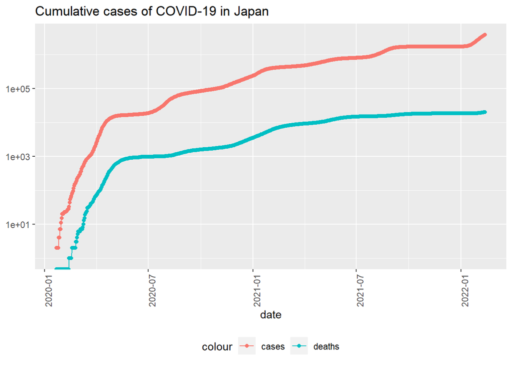

```r
japan_total %>%
  ggplot(aes(x=date, y=cases)) +
  geom_line(aes(color = "cases")) +
  geom_point(aes(color = "cases")) +
  geom_line(aes(y = deaths, color = "deaths")) +
  geom_point(aes(y = deaths, color = "deaths")) +
  scale_y_log10() +
  theme(legend.position = "bottom", axis.text.x = element_text(angle = 90)) +
  labs(title = "Cumulative cases of COVID-19 in Japan", y = NULL)
```

### (3) New cases trends

Is there any trend of new cases?

I will add new variables.

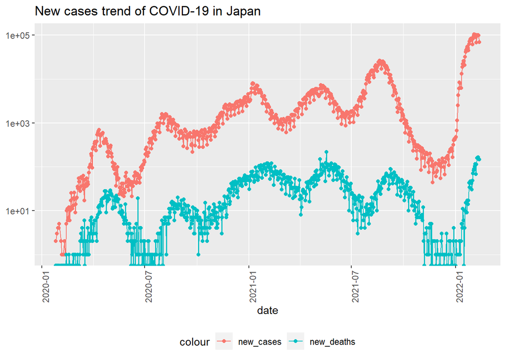

```r
japan_total <- japan_total %>%
  mutate(new_cases = cases - lag(cases), new_deaths = deaths - lag(deaths))


japan_total %>%
  filter(cases > 0) %>%
  filter(new_cases > 0) %>%
  ggplot(aes(x = date, y = new_cases)) +
  geom_line(aes(color = "new_cases")) +
  geom_point(aes(color = "new_cases")) +
  geom_line(aes(y = new_deaths, color = "new_deaths")) +
  geom_point(aes(y = new_deaths, color = "new_deaths")) +
  scale_y_log10() + theme(legend.position = "bottom", axis.text.x = element_text(angle = 90)) +
  labs(title = "New cases trend of COVID-19 in Japan", y = NULL)
```

#### Analysis

This graph shows that number of new cases is fluctuating but clearly its number had been decreasing from September to December 2021.

### (4) Additional thought - Vaccination effect -

What is the background of this down trend?

I will use global vaccination data from the same JHU site.

Then I will join this data into the above Japaneses data.

```r
global_vaccine <- read_csv(url("https://github.com/govex/COVID-19/raw/master/data_tables/vaccine_data/global_data/time_series_covid19_vaccine_global.csv"))
summary(global_vaccine)
```

```
##  Country_Region          Date             Doses_admin
##  Length:168316      Min.   :2020-12-14   Min.   :0.000e+00
##  Class :character   1st Qu.:2021-07-22   1st Qu.:2.757e+05
##  Mode  :character   Median :2021-10-06   Median :1.146e+06
##                     Mean   :2021-09-24   Mean   :2.471e+07
##                     3rd Qu.:2021-12-13   3rd Qu.:5.111e+06
##                     Max.   :2022-02-11   Max.   :1.019e+10
##                                          NA's   :5288
##  People_partially_vaccinated People_fully_vaccinated Report_Date_String
##  Min.   :0.000e+00           Min.   :0.000e+00       Min.   :2020-12-14
##  1st Qu.:1.866e+05           1st Qu.:4.584e+04       1st Qu.:2021-07-23
##  Median :1.057e+06           Median :6.159e+05       Median :2021-10-07
##  Mean   :3.033e+07           Mean   :2.210e+07       Mean   :2021-09-25
##  3rd Qu.:5.745e+06           3rd Qu.:3.995e+06       3rd Qu.:2021-12-14
##  Max.   :4.755e+09           Max.   :4.124e+09       Max.   :2022-02-12
##  NA's   :107458              NA's   :107458
##       UID         Province_State
##  Min.   :     4   Length:168316
##  1st Qu.:   516   Class :character
##  Median : 12406   Mode  :character
##  Mean   : 45548
##  3rd Qu.: 44007
##  Max.   :524008
##  NA's   :475
```

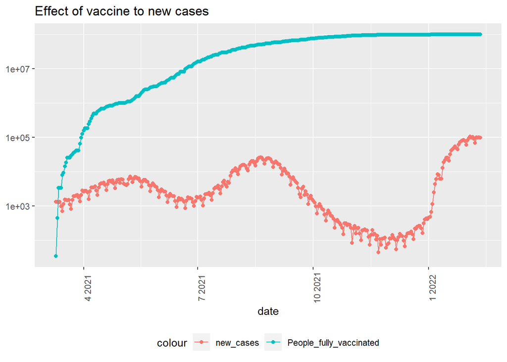

```r
japan_vaccine <- global_vaccine %>%
  filter(Country_Region == "Japan") %>%
  rename(date = 'Date')

japan_total_vaccine <- japan_total %>% full_join(japan_vaccine, by="date")

japan_total_vaccine %>%
  filter(new_cases > 0) %>%
  filter(People_fully_vaccinated > 0) %>%
  ggplot(aes(x = date, y = new_cases)) +
  geom_line(aes(color = "new_cases")) +
  geom_point(aes(color = "new_cases")) +
  geom_line(aes(y = People_fully_vaccinated, color = "People_fully_vaccinated")) +
  geom_point(aes(y = People_fully_vaccinated, color = "People_fully_vaccinated")) +
  scale_y_log10() + theme(legend.position = "bottom", axis.text.x = element_text(angle = 90)) +
  labs(title = "Effect of vaccine to new cases", y = NULL)
```

#### Analysis

This graph explains that the full vaccination will give effect to the decreasing trend from September to December 2021.

But the skyrocketing number from December may be another background where the vaccine is not so valid for new mutated virus or other type of infection had occurred among non-vaccinated people such as young people who had not been eligible for vaccination.

Note that data may be biased. This graph shows that infection rate and deaths rate is correlated, but from the view point of the age of the infected person, deaths may not be directly causal relationship with infection. The old aged people could die because of other fundamental diseases.

## 4. Correlation between deaths and infection cases

Common sense may explain: if the COVID-19 cases are found many times, many deaths cases caused by COVID-19 may also be found.

Is there any statistical evidence to prove the above gut feeling?

I will use global data of the JHU site.

Then, I will add new 2 parameter “case_per_thou” and “deaths_per_thou” which function the numbers are standardized by the 1,000 population.

```r
global_country_total <- global %>%
  group_by(Country_Region) %>%
  summarize(deaths = max(deaths), cases = max(cases), population = max(Population), cases_per_thou = 1000 * cases / population,       deaths_per_thou = 1000 * deaths / population) %>%
  filter(cases > 0, population > 0)

summary(global_country_total)
```

```
##  Country_Region         deaths             cases            population
##  Length:191         Min.   :     0.0   Min.   :       1   Min.   :8.090e+02
##  Class :character   1st Qu.:   387.5   1st Qu.:   34882   1st Qu.:2.023e+06
##  Mode  :character   Median :  3015.0   Median :  261226   Median :8.656e+06
##                     Mean   : 30169.5   Mean   : 2116319   Mean   :3.273e+07
##                     3rd Qu.: 15641.0   3rd Qu.: 1176250   3rd Qu.:2.806e+07
##                     Max.   :919253.0   Max.   :77707349   Max.   :1.380e+09
##  cases_per_thou     deaths_per_thou
##  Min.   :  0.0088   Min.   :0.00000
##  1st Qu.:  6.6534   1st Qu.:0.09899
##  Median : 67.9154   Median :0.61804
##  Mean   :100.9889   Mean   :1.05726
##  3rd Qu.:148.4482   3rd Qu.:1.63973
##  Max.   :480.6834   Max.   :6.30735
```

### Prediction

Then, I assume that the standardized case and the standardized deaths case may be linearly correlated.

```r
mod <- lm(deaths_per_thou ~ cases_per_thou, data = global_country_total)

summary(mod)
```

```
##
## Call:
## lm(formula = deaths_per_thou ~ cases_per_thou, data = global_country_total)
##
## Residuals:
##     Min      1Q  Median      3Q     Max
## -2.2460 -0.4010 -0.2981  0.2249  5.2315
##
## Coefficients:
##                 Estimate Std. Error t value Pr(>|t|)
## (Intercept)    0.4050033  0.0922501    4.39 1.88e-05 ***
## cases_per_thou 0.0064588  0.0006135   10.53  < 2e-16 ***
## ---
## Signif. codes:  0 '***' 0.001 '**' 0.01 '*' 0.05 '.' 0.1 ' ' 1
##
## Residual standard error: 0.9445 on 189 degrees of freedom
## Multiple R-squared:  0.3696, Adjusted R-squared:  0.3663
## F-statistic: 110.8 on 1 and 189 DF,  p-value: < 2.2e-16
```

```r
global_country_total %>% slice_max(cases_per_thou)
```

```
## # A tibble: 1 x 6
##   Country_Region deaths cases population cases_per_thou deaths_per_thou
##   <chr>           <dbl> <dbl>      <dbl>          <dbl>           <dbl>
## 1 Andorra           148 37140      77265           481.            1.92
```

```r
global_country_total %>% slice_min(cases_per_thou)
```

```
## # A tibble: 1 x 6
##   Country_Region deaths cases population cases_per_thou deaths_per_thou
##   <chr>           <dbl> <dbl>      <dbl>          <dbl>           <dbl>
## 1 Micronesia          0     1     113815        0.00879               0
```

```r
x_grid <- seq(1,151)

new_df <- tibble(cases_per_thou = x_grid)

global_country_total %>% mutate(pred = predict(mod))
```

```
## # A tibble: 191 x 7
##    Country_Region  deaths  cases population cases_per_thou deaths_per_thou  pred
##    <chr>            <dbl>  <dbl>      <dbl>          <dbl>           <dbl> <dbl>
##  1 Afghanistan       7488 1.70e5   38928341           4.37          0.192  0.433
##  2 Albania           3407 2.68e5    2877800          93.0           1.18   1.01
##  3 Algeria           6715 2.61e5   43851043           5.96          0.153  0.443
##  4 Andorra            148 3.71e4      77265         481.            1.92   3.51
##  5 Angola            1898 9.85e4   32866268           3.00          0.0577 0.424
##  6 Antigua and Ba~    134 7.33e3      97928          74.9           1.37   0.889
##  7 Argentina       123987 8.73e6   45195777         193.            2.74   1.65
##  8 Armenia           8157 4.05e5    2963234         137.            2.75   1.29
##  9 Australia         2284 1.20e6    8118000         148.            0.281  1.36
## 10 Austria          14360 2.25e6    9006400         250.            1.59   2.02
## # ... with 181 more rows
```

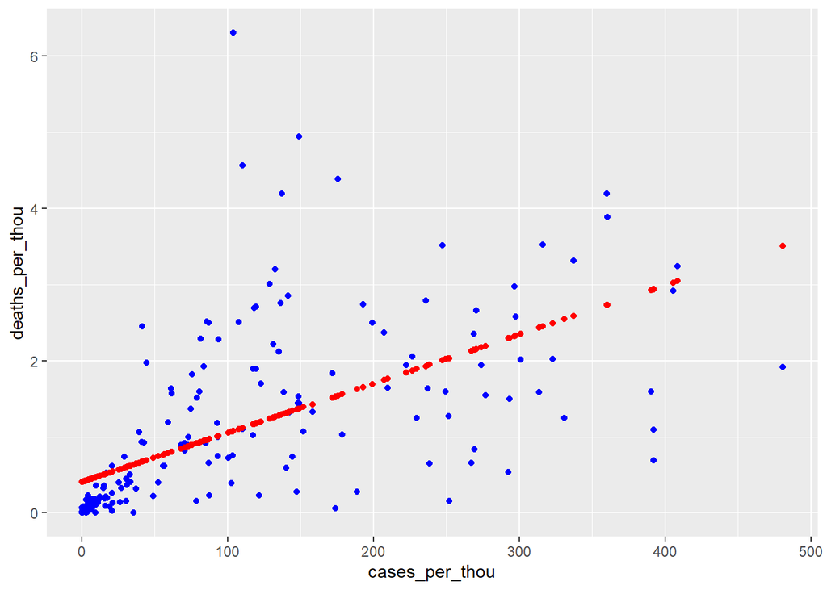

```r
global_total_pred <- global_country_total %>% mutate(pred = predict(mod))

global_total_pred %>% ggplot()+
  geom_point(aes(x=cases_per_thou, y=deaths_per_thou), color="blue")+
  geom_point(aes(x=cases_per_thou, y=pred), color = "red")
```

#### Analysis

This graph depicts that the cases and deaths are linearly related, but there are several points where the number of deaths per population is much higher than linear predicted line.

This data may show that at the above points (countries), vaccine had not been fully supplied.

Note that the data may be biased. Especially the small number of infection per population might suggest that the country adopted “zero-corona” policy or the country did not have enough inspection devices. So the number might be underestimated.

## 5. Conclusion

This report shows historical trends of COVID-19 cases in Japan.

With regard to the correlation analysis, this report shows that the globally collected data explains that the number of infection cases and the number of deaths, which of both are standardized by the population of each country, are linearly related.